# Checking MATLAB Output

Ghislain d’Entremont

March 4, 2017

# Load Packages

```r
library(signal)
library(tidyverse)
library(rstan)
library(bspec)
```

# Load and Tidy Data

##### We start with the raw data.

```r
setwd("/Volumes/LaCie/Experiments/NF_data")

raw = map_df(
  .x = list.files(
    pattern = "2_raw"
  )
  , .f = function(file) {
    read_csv(
      file = file
      , col_names = FALSE
    )
  }
)

names(raw) = c('id', 'age', 'sex', 'hand', 'year', 'month', 'day', 'hour', 'minute', 'seconds', 'block' , 'block_cond', 'trial', 'cue_loc', 'iti', 'trial_stage', 'iteration', 'time', 'Ch1', 'Ch2', 'Ch3', 'Ch4', 'Ch5', 'Ch6', 'Ch7', 'Ch8', 'Ch9', 'Ch10', 'Ch11', 'Ch12', 'Ch13', 'Ch14')

raw$id = factor(raw$id)
raw$sex = factor(raw$sex, levels = c(1, 2), labels = c("male", "female"))
raw$hand = factor(raw$hand, levels = c(1, 2), labels = c("left", "right"))
raw$block = factor(raw$block)
raw$block_cond = factor(raw$block_cond, levels = c(1, 2), labels = c("MI", "ME"))
raw$cue_loc = factor(raw$cue_loc, levels = c(1, 2), labels = c("left", "right"))
raw$trial_stage = factor(raw$trial_stage, levels = c(1:4), labels = c("iti", "fixation", "cue", "NF"))

summary(raw)
```

```
##  id              age         sex            hand             year
##  2:178880   Min.   :22   male  :178880   left :     0   Min.   :2017
##             1st Qu.:22   female:     0   right:178880   1st Qu.:2017
##             Median :22                                  Median :2017
##             Mean   :22                                  Mean   :2017
##             3rd Qu.:22                                  3rd Qu.:2017
##             Max.   :22                                  Max.   :2017
##      month        day         hour        minute     seconds
##  Min.   :3   Min.   :3   Min.   :14   Min.   :5   Min.   :48.79
##  1st Qu.:3   1st Qu.:3   1st Qu.:14   1st Qu.:5   1st Qu.:48.79
##  Median :3   Median :3   Median :14   Median :5   Median :48.79
##  Mean   :3   Mean   :3   Mean   :14   Mean   :5   Mean   :48.79
##  3rd Qu.:3   3rd Qu.:3   3rd Qu.:14   3rd Qu.:5   3rd Qu.:48.79
##  Max.   :3   Max.   :3   Max.   :14   Max.   :5   Max.   :48.79
##  block     block_cond      trial       cue_loc           iti
##  1:79816   MI:     0   Min.   : 1.0   left :54816   Min.   :1.020
##  2:99064   ME:178880   1st Qu.:16.0   right:54720   1st Qu.:1.243
##                        Median :32.0   NA's :69344   Median :1.490
##                        Mean   :31.5                 Mean   :1.503
##                        3rd Qu.:47.0                 3rd Qu.:1.769
##                        Max.   :60.0                 Max.   :2.000
##    trial_stage      iteration           time              Ch1
##  iti     :39207   Min.   :  1.00   Min.   :  88.62   Min.   :3709
##  fixation:30137   1st Qu.: 19.00   1st Qu.: 438.00   1st Qu.:4146
##  cue     :33288   Median : 38.00   Median : 787.38   Median :4150
##  NF      :76248   Mean   : 42.26   Mean   : 787.37   Mean   :4150
##                   3rd Qu.: 64.00   3rd Qu.:1136.72   3rd Qu.:4155
##                   Max.   :120.00   Max.   :1486.10   Max.   :4380
##       Ch2            Ch3            Ch4            Ch5
##  Min.   :3872   Min.   :3877   Min.   :3870   Min.   :1880
##  1st Qu.:4148   1st Qu.:4159   1st Qu.:4173   1st Qu.:4138
##  Median :4150   Median :4160   Median :4177   Median :4143
##  Mean   :4150   Mean   :4161   Mean   :4177   Mean   :4143
##  3rd Qu.:4152   3rd Qu.:4162   3rd Qu.:4180   3rd Qu.:4147
##  Max.   :4317   Max.   :4620   Max.   :5170   Max.   :6382
##       Ch6            Ch7            Ch8            Ch9
##  Min.   :3804   Min.   :3327   Min.   :3880   Min.   :2993
##  1st Qu.:4138   1st Qu.:4128   1st Qu.:4154   1st Qu.:4163
##  Median :4142   Median :4132   Median :4156   Median :4169
##  Mean   :4142   Mean   :4132   Mean   :4156   Mean   :4169
##  3rd Qu.:4146   3rd Qu.:4136   3rd Qu.:4158   3rd Qu.:4176
##  Max.   :4383   Max.   :5172   Max.   :4557   Max.   :4968
##       Ch10           Ch11           Ch12           Ch13
##  Min.   :3811   Min.   :3702   Min.   :3977   Min.   :3225
##  1st Qu.:4155   1st Qu.:4204   1st Qu.:4920   1st Qu.:4188
##  Median :4160   Median :4208   Median :4924   Median :4195
##  Mean   :4160   Mean   :4208   Mean   :4921   Mean   :4195
##  3rd Qu.:4164   3rd Qu.:4212   3rd Qu.:4926   3rd Qu.:4202
##  Max.   :4328   Max.   :5073   Max.   :6496   Max.   :5225
##       Ch14
##  Min.   :3638
##  1st Qu.:4142
##  Median :4149
##  Mean   :4149
##  3rd Qu.:4156
##  Max.   :4652
```

```r
raw_long = raw %>%
  gather(channel, signal, Ch1:Ch14, factor_key = TRUE)

summary(raw_long)
```

```
##  id               age         sex             hand              year
##  2:2504320   Min.   :22   male  :2504320   left :      0   Min.   :2017
##              1st Qu.:22   female:      0   right:2504320   1st Qu.:2017
##              Median :22                                    Median :2017
##              Mean   :22                                    Mean   :2017
##              3rd Qu.:22                                    3rd Qu.:2017
##              Max.   :22                                    Max.   :2017
##
##      month        day         hour        minute     seconds
##  Min.   :3   Min.   :3   Min.   :14   Min.   :5   Min.   :48.79
##  1st Qu.:3   1st Qu.:3   1st Qu.:14   1st Qu.:5   1st Qu.:48.79
##  Median :3   Median :3   Median :14   Median :5   Median :48.79
##  Mean   :3   Mean   :3   Mean   :14   Mean   :5   Mean   :48.79
##  3rd Qu.:3   3rd Qu.:3   3rd Qu.:14   3rd Qu.:5   3rd Qu.:48.79
##  Max.   :3   Max.   :3   Max.   :14   Max.   :5   Max.   :48.79
##
##  block       block_cond       trial       cue_loc            iti
##  1:1117424   MI:      0   Min.   : 1.0   left :767424   Min.   :1.020
##  2:1386896   ME:2504320   1st Qu.:16.0   right:766080   1st Qu.:1.243
##                           Median :32.0   NA's :970816   Median :1.490
##                           Mean   :31.5                  Mean   :1.503
##                           3rd Qu.:47.0                  3rd Qu.:1.769
##                           Max.   :60.0                  Max.   :2.000
##
##    trial_stage        iteration           time            channel
##  iti     : 548898   Min.   :  1.00   Min.   :  88.62   Ch1    : 178880
##  fixation: 421918   1st Qu.: 19.00   1st Qu.: 438.00   Ch2    : 178880
##  cue     : 466032   Median : 38.00   Median : 787.38   Ch3    : 178880
##  NF      :1067472   Mean   : 42.26   Mean   : 787.37   Ch4    : 178880
##                     3rd Qu.: 64.00   3rd Qu.:1136.72   Ch5    : 178880
##                     Max.   :120.00   Max.   :1486.10   Ch6    : 178880
##                                                        (Other):1431040
##      signal
##  Min.   :1880
##  1st Qu.:4147
##  Median :4158
##  Mean   :4215
##  3rd Qu.:4178
##  Max.   :6496
##
```

##### Now we look at the transformed (power) data.

```r
setwd("/Volumes/LaCie/Experiments/NF_data")

pwr = map_df(
  .x = list.files(
    pattern = "2_pwr"
  )
  , .f = function(file) {
    read_csv(
      file = file
      , col_names = FALSE
    )
  }
)

names(pwr) = c('id', 'age', 'sex', 'hand', 'year', 'month', 'day', 'hour', 'minute', 'seconds', 'block' , 'block_cond', 'trial', 'cue_loc', 'iti', 'trial_stage', 'iteration', 'baseline_power_mavg', 'C3', 'C4', 'LI')

pwr$id = factor(pwr$id)
pwr$sex = factor(pwr$sex, levels = c(1, 2), labels = c("male", "female"))
pwr$hand = factor(pwr$hand, levels = c(1, 2), labels = c("left", "right"))
pwr$block = factor(pwr$block)
pwr$block_cond = factor(pwr$block_cond, levels = c(1, 2), labels = c("MI", "ME"))
pwr$cue_loc = factor(pwr$cue_loc, levels = c(1, 2), labels = c("left", "right"))
pwr$trial_stage = factor(pwr$trial_stage, levels = c(1:4), labels = c("iti", "fixation", "cue", "NF"))

summary(pwr)
```

```
##  id             age         sex           hand            year
##  2:36526   Min.   :22   male  :36526   left :    0   Min.   :2017
##            1st Qu.:22   female:    0   right:36526   1st Qu.:2017
##            Median :22                                Median :2017
##            Mean   :22                                Mean   :2017
##            3rd Qu.:22                                3rd Qu.:2017
##            Max.   :22                                Max.   :2017
##
##      month        day         hour        minute     seconds
##  Min.   :3   Min.   :3   Min.   :14   Min.   :5   Min.   :48.79
##  1st Qu.:3   1st Qu.:3   1st Qu.:14   1st Qu.:5   1st Qu.:48.79
##  Median :3   Median :3   Median :14   Median :5   Median :48.79
##  Mean   :3   Mean   :3   Mean   :14   Mean   :5   Mean   :48.79
##  3rd Qu.:3   3rd Qu.:3   3rd Qu.:14   3rd Qu.:5   3rd Qu.:48.79
##  Max.   :3   Max.   :3   Max.   :14   Max.   :5   Max.   :48.79
##
##  block     block_cond     trial        cue_loc           iti
##  1:18240   MI:    0   Min.   : 1.00   left :10500   Min.   :1.020
##  2:18286   ME:36526   1st Qu.:16.00   right:10500   1st Qu.:1.262
##                       Median :31.00   NA's :15526   Median :1.490
##                       Mean   :30.53                 Mean   :1.508
##                       3rd Qu.:45.00                 3rd Qu.:1.769
##                       Max.   :60.00                 Max.   :2.000
##
##    trial_stage      iteration      baseline_power_mavg       C3
##  iti     :10726   Min.   :  1.00   Min.   :  0.223     Min.   :    0.000
##  fixation: 4800   1st Qu.: 20.00   1st Qu.:  0.277     1st Qu.:    0.206
##  cue     : 9000   Median : 39.00   Median :  0.296     Median :    0.240
##  NF      :12000   Mean   : 42.41   Mean   :  4.235     Mean   :   14.512
##                   3rd Qu.: 63.00   3rd Qu.:  0.321     3rd Qu.:    0.279
##                   Max.   :120.00   Max.   :367.110     Max.   :12651.000
##                                    NA's   :24526
##        C4                  LI
##  Min.   :    0.000   Min.   :-1.384
##  1st Qu.:    0.303   1st Qu.: 0.277
##  Median :    0.356   Median : 0.584
##  Mean   :   26.040   Mean   : 0.605
##  3rd Qu.:    0.418   3rd Qu.: 0.891
##  Max.   :20796.000   Max.   : 4.819
##                      NA's   :24526
```

```r
pwr_long = pwr %>%
  gather(channel, signal, c(C3, C4), factor_key = TRUE)

summary(pwr_long)
```

```
##  id             age         sex           hand            year
##  2:73052   Min.   :22   male  :73052   left :    0   Min.   :2017
##            1st Qu.:22   female:    0   right:73052   1st Qu.:2017
##            Median :22                                Median :2017
##            Mean   :22                                Mean   :2017
##            3rd Qu.:22                                3rd Qu.:2017
##            Max.   :22                                Max.   :2017
##
##      month        day         hour        minute     seconds
##  Min.   :3   Min.   :3   Min.   :14   Min.   :5   Min.   :48.79
##  1st Qu.:3   1st Qu.:3   1st Qu.:14   1st Qu.:5   1st Qu.:48.79
##  Median :3   Median :3   Median :14   Median :5   Median :48.79
##  Mean   :3   Mean   :3   Mean   :14   Mean   :5   Mean   :48.79
##  3rd Qu.:3   3rd Qu.:3   3rd Qu.:14   3rd Qu.:5   3rd Qu.:48.79
##  Max.   :3   Max.   :3   Max.   :14   Max.   :5   Max.   :48.79
##
##  block     block_cond     trial        cue_loc           iti
##  1:36480   MI:    0   Min.   : 1.00   left :21000   Min.   :1.020
##  2:36572   ME:73052   1st Qu.:16.00   right:21000   1st Qu.:1.262
##                       Median :31.00   NA's :31052   Median :1.490
##                       Mean   :30.53                 Mean   :1.508
##                       3rd Qu.:45.00                 3rd Qu.:1.769
##                       Max.   :60.00                 Max.   :2.000
##
##    trial_stage      iteration      baseline_power_mavg       LI
##  iti     :21452   Min.   :  1.00   Min.   :  0.22      Min.   :-1.38
##  fixation: 9600   1st Qu.: 20.00   1st Qu.:  0.28      1st Qu.: 0.28
##  cue     :18000   Median : 39.00   Median :  0.30      Median : 0.58
##  NF      :24000   Mean   : 42.41   Mean   :  4.24      Mean   : 0.60
##                   3rd Qu.: 63.00   3rd Qu.:  0.32      3rd Qu.: 0.89
##                   Max.   :120.00   Max.   :367.11      Max.   : 4.82
##                                    NA's   :49052       NA's   :49052
##  channel        signal
##  C3:36526   Min.   :    0.000
##  C4:36526   1st Qu.:    0.235
##             Median :    0.291
##             Mean   :   20.276
##             3rd Qu.:    0.364
##             Max.   :20796.000
##
```

# Look at Raw Data

##### We verify that time stamps are accurate. Indeed, the difference between the time stamps and the expected time points (based on sampling frequency) are varies closely around 0.

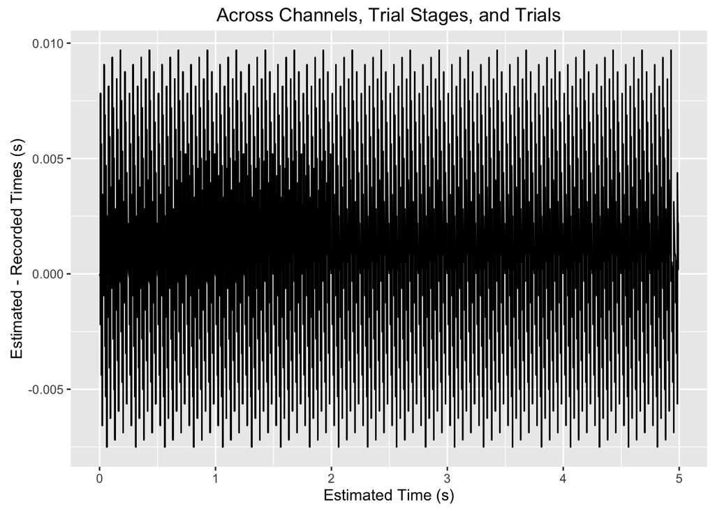

```r
raw_long = raw_long %>%
  group_by(block, trial, trial_stage, channel) %>%
  mutate(
    time_adj = time - min(time)
    , time_est = seq(0, (1/128)*(length(id)-1), by = 1/128)
    )

raw_long %>%
  dplyr::filter(block == 1, trial < 10) %>%
  ggplot(aes(x = time_est, y = time_est - time_adj))+
    geom_line()+
    ggtitle("Across Channels, Trial Stages, and Trials")+
    xlab("Estimated Time (s)")+
    ylab("Estimated - Recorded Times (s)")
```

##### Look at raw waveforms and epochs.

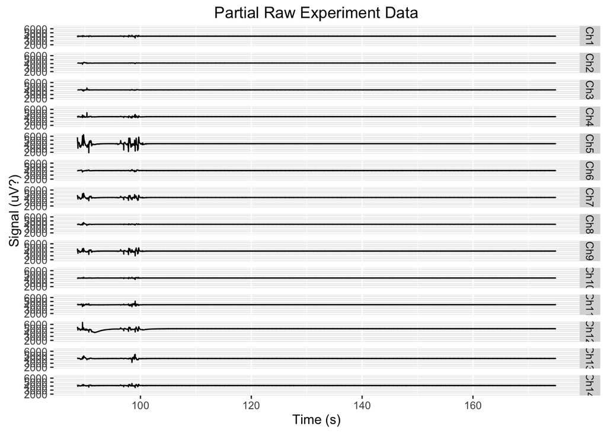

```r
raw_long %>%
  dplyr::filter(block == 1, trial < 10) %>%
  ggplot(aes(y = signal, x = time))+
    geom_line()+
    facet_grid(channel ~.)+
    ggtitle("Partial Raw Experiment Data")+
    xlab("Time (s)")+
    ylab("Signal (uV?)")
```

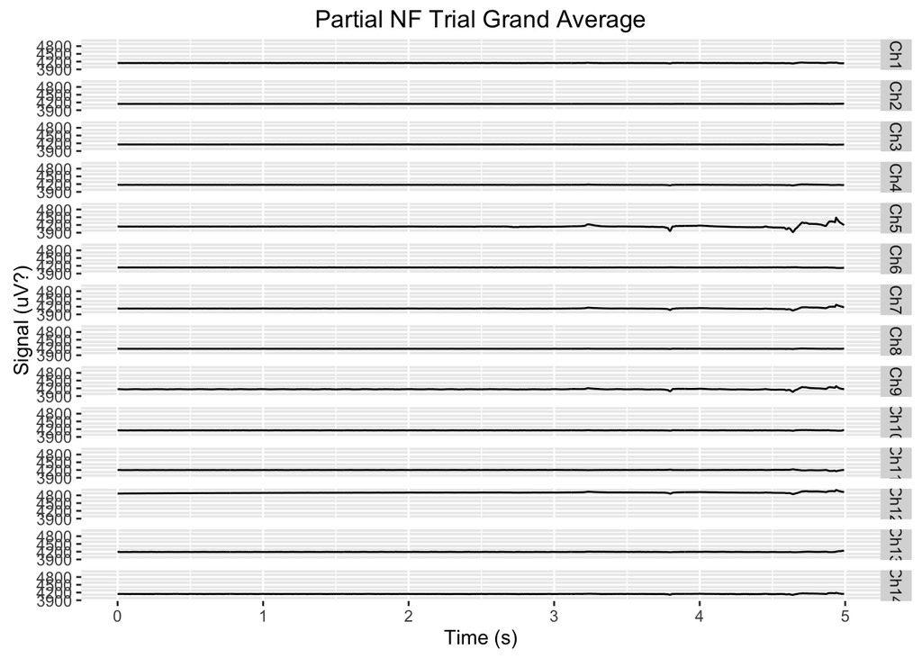

```r
raw_long %>%
  dplyr::filter(trial_stage == "NF", block == 1, trial < 10) %>%
  group_by(channel, time_est) %>%
  summarize(avg_signal = mean(signal)) %>%
  ggplot(aes(y = avg_signal, x = time_est))+
    geom_line()+
    facet_grid(channel~.)+
    ggtitle("Partial NF Trial Grand Average")+
    xlab("Time (s)")+
    ylab("Signal (uV?)")
```

##### We look to create power values from raw data. We will attempt this without the use of a ‘data buffer’. For each trial stage we will (1) butterworth (2) notch and (3) take the power values.

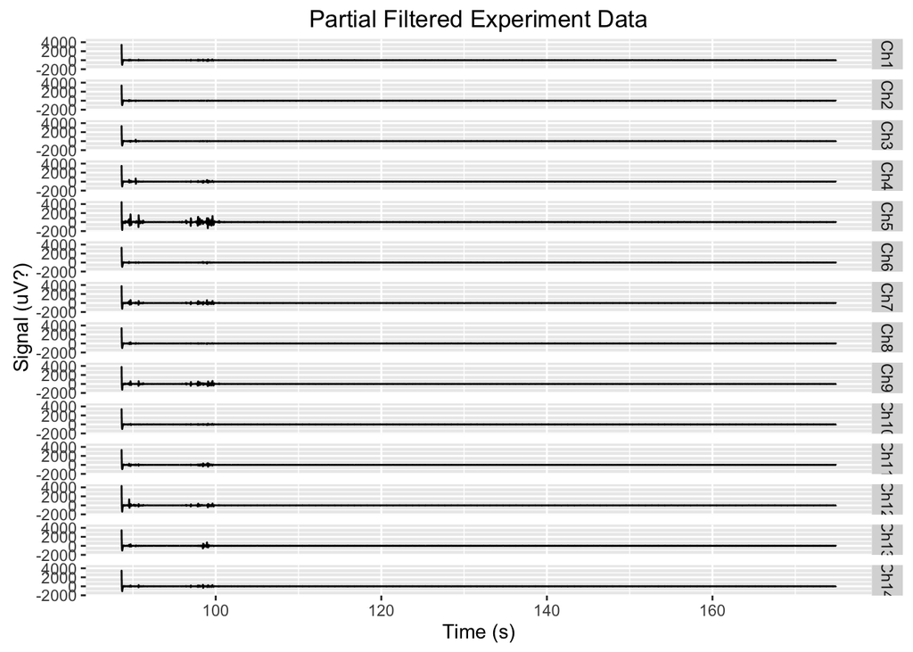

```r
bu = butter(2, c(4,60)/(128/2), type = 'pass')
no = butter(2, c(59,61)/(128/2), type = 'stop')

raw_long_fil= raw_long %>%
  group_by(channel) %>%
  mutate(butter_filtered = signal::filter(bu, signal)) %>%
  mutate(and_notch_filtered = signal::filter(no, butter_filtered))

raw_long_fil %>%
  dplyr::filter(block == 1, trial < 10) %>%
  ggplot(aes(y = and_notch_filtered, x = time))+
    geom_line()+
    facet_grid(channel ~.)+
    ggtitle("Partial Filtered Experiment Data")+
    xlab("Time (s)")+
    ylab("Signal (uV?)")
```

```r
raw_long_pwr = raw_long_fil %>%
  dplyr::filter(channel == "Ch8" || channel == "Ch12") %>%
  group_by(block, trial, trial_stage, cue_loc, channel) %>%
  summarize(power = mean(welchPSD(ts(and_notch_filtered), seglength = 128)[["power"]][14:31]))
```

##### Let’s compare the calculated power values to those that were computed in realtime in MATLAB. We see a very strong positive relationship between these power values for each channel. The discrency appears to lie in the magnitudes of the values, with the MATLAB computed power values being quite a bit smaller. The power values computed in real time were taken from smaller time windows and averaged (moving averages were themselves averaged), whereas those computed above were done for each trial stage.

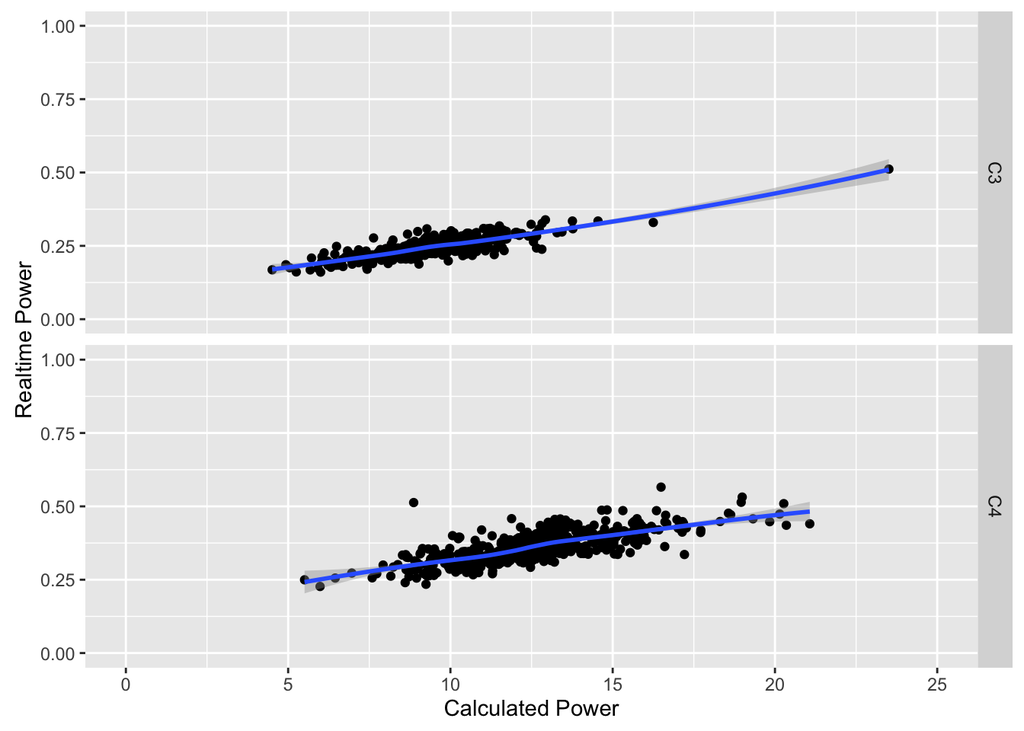

```r
pwr_cal = raw_long_pwr %>%
  group_by(block, trial, trial_stage, channel) %>%
  summarize(avg_cal = mean(power))

pwr_real = pwr_long %>%
  group_by(block, trial, trial_stage, channel) %>%
  summarize(avg_real = mean(signal))

pwr_compare = bind_cols(pwr_cal[, -4], pwr_real)

pwr_compare %>%
  ggplot(aes(x = avg_cal, y = avg_real))+
    geom_point()+
    geom_smooth()+
    facet_grid(channel~.)+
    xlab("Calculated Power")+
    ylab("Realtime Power")+
    xlim(c(0,25))+  # to ignore outliers
    ylim(c(0,1))
```

```r
pwr_compare[,-c(1,2,3)] %>%
  group_by(channel) %>%
  summarize(corr = cor(avg_cal, avg_real, use = "complete"))
```

```
## # A tibble: 2 × 2
##   channel      corr
##    <fctr>     <dbl>
## 1      C3 0.9987960
## 2      C4 0.9947866
```

##### Now, we can compute baseline power values from our calculated power values and compare those with those of the realtime MATAB output. We see that despite the relationship being nearly perfect (above), there is some kind of relationship between the moving average baseline from the realtime MATLAB output and that from calculated from the raw data. It is difficult to assess since the unsually large calculated power values from the early trials, by-products of filtering (see filtered data above), inflate the early average estimates. The correlation is still fairly high. The solution, if analysis of the raw data is prefered, may involve collecting some junk data prior to trial 1.

```r
baseline_pwr_cal = pwr_cal %>%
  dplyr::filter(trial_stage == "fixation") %>%
  group_by(block, trial) %>%
  summarize(baseline = mean(avg_cal))

window = NULL
mavgs = NULL
for (i in 1:nrow(baseline_pwr_cal)) {
  window = c(window, baseline_pwr_cal$baseline[i])

  if (length(window) > 40) {
      window_40 = window[1:40]
  } else {
    window_40 = window
  }

  mavg = mean(window_40)
  mavgs = c(mavgs, mavg)
}

mavg_pwr_cal = tibble(cal_mavg = mavgs, block = baseline_pwr_cal$block, trial = baseline_pwr_cal$trial)

mavg_pwr_real = pwr_long %>%
  dplyr::filter(trial_stage == "NF") %>%
  group_by(block, trial) %>%
  summarize(real_mavg = mean(baseline_power_mavg)) %>%
  slice(1:nrow(mavg_pwr_cal))

mavg_compare = left_join(mavg_pwr_cal, mavg_pwr_real)
```

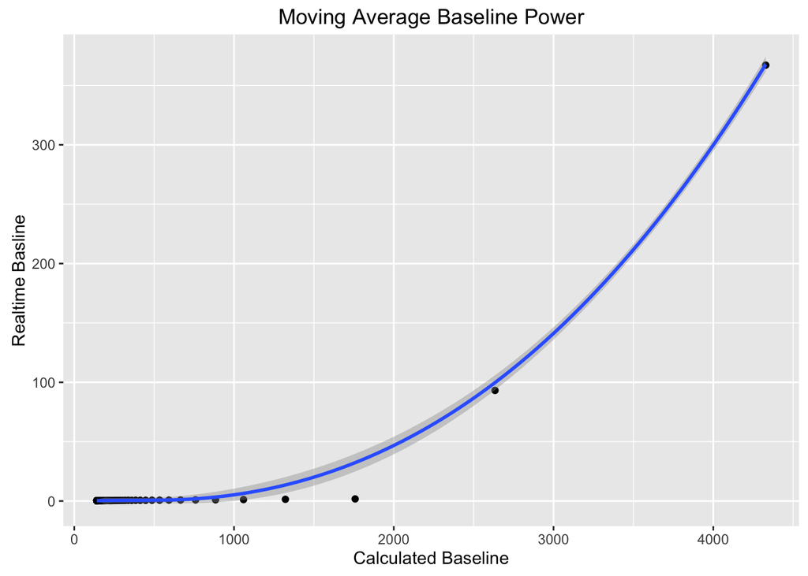

```r
mavg_compare %>%
  ggplot(aes(x = cal_mavg, y = real_mavg))+
    geom_point()+
    geom_smooth()+
    ggtitle("Moving Average Baseline Power")+
    xlab("Calculated Baseline")+
    ylab("Realtime Basline")
```

```r
cor(mavg_compare$cal_mavg, mavg_compare$real_mavg)
```

```
## [1] 0.8514003
```

##### To esure that the LIs (the parameter of interest) is the same whether computed online or offline, we compute LIs for each trial using raw data and compare those to the average of those computed in real time. Interestingly the LIs seem to be related strongly and in logistic manner as can be seen my the model fit. The correlation comes out to be very large.

```r
LI_cal = raw_long_pwr %>%
  dplyr::filter(trial_stage == "NF") %>%
  left_join(mavg_pwr_cal) %>%
  spread(key = channel, power) %>%
  mutate(
    LI_cal = ifelse(
      cue_loc == "right"
      , log2(Ch12/cal_mavg) - log2(Ch8/cal_mavg)
      , log2(Ch8/cal_mavg) - log2(Ch12/cal_mavg)
    )
  )
```

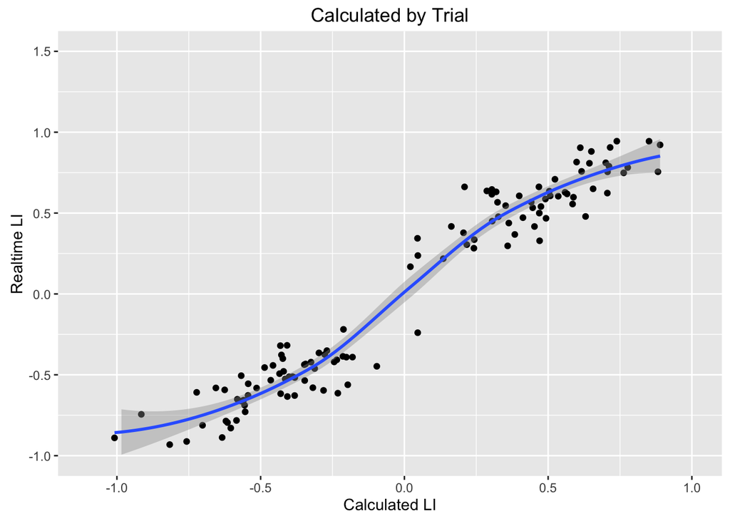

```r
LI_real = pwr_long %>%
  mutate(
    LI_pos = ifelse(
        cue_loc == "right"
        , LI
        , -LI
      )
    ) %>%
  dplyr::filter(trial_stage == "NF") %>%
  group_by(block, trial) %>%
  summarize(avg_LI = mean(LI_pos))

LI_compare = bind_cols(LI_cal, LI_real[,-c(1:2)])

LI_compare %>%
  ggplot(aes(x = LI_cal, y = avg_LI))+
    geom_point()+
    geom_smooth()+
    ggtitle("Calculated by Trial")+
    xlab("Calculated LI")+
    ylab("Realtime LI")+
    xlim(c(-1.1, 1))+
    ylim(c(-1,1.5))
```

```r
cor(LI_compare$LI_cal, LI_compare$avg_LI)
```

```
## [1] 0.9200903
```

# Look at Real Time Data

##### First, we’ll examine the timestamps. In at least some cases the timing of a particular time_stage was perfect (looking at max iteration). However, looking at the median, we see that there is timing issue - one that likely relates to the slowed screen flipping later in the experiment run.

```r
pwr_long %>%
  group_by(trial_stage) %>%
  summarize(
    perfect_stage_time = ifelse(
      trial_stage == "NF" || trial_stage == "fixation"
      , max(iteration)*(1/60)*3
      , max(iteration)*(1/60)*1
      )
    , median_stage_time = ifelse(
      trial_stage == "NF" || trial_stage == "fixation"
      , median(iteration)*(1/60)*3
      , median(iteration)*(1/60)*1
      )
    )
```

```
## # A tibble: 4 × 3
##   trial_stage perfect_stage_time median_stage_time
##        <fctr>              <dbl>             <dbl>
## 1         iti               2.00         0.7500000
## 2    fixation               2.00         1.0250000
## 3         cue               1.25         0.6333333
## 4          NF               5.00         2.5250000
```

We see power spikes during the iti phase. Also, we see a sharp increase in power at the very end of the NF phase. The last plot shows that these power spikes are due to the early trial filtering artifacts.

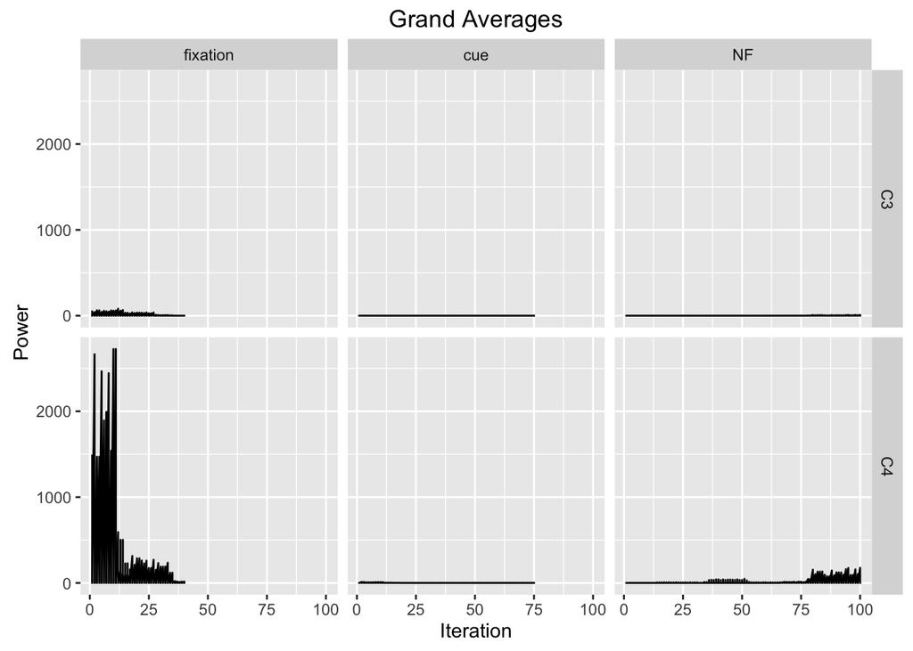

```r
pwr_long %>%
  dplyr::filter(trial_stage != "iti") %>%
  group_by(block, trial, trial_stage, iteration, channel) %>%
  summarize(avg_signal = mean(signal)) %>%
  ggplot(aes(y = avg_signal, x = iteration))+
    geom_line()+
    facet_grid(channel~trial_stage)+
    ggtitle("Grand Averages")+
    xlab("Iteration")+
    ylab("Power")
```

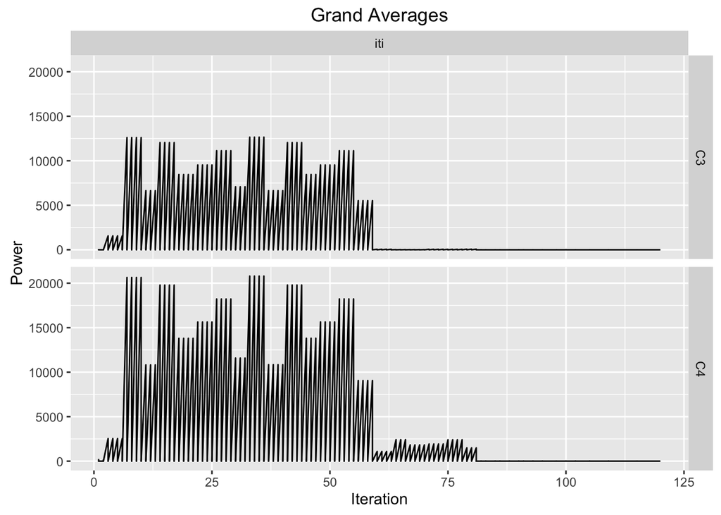

```r
pwr_long %>%
  dplyr::filter(trial_stage == "iti") %>%
  group_by(block, trial, trial_stage, iteration, channel) %>%
  summarize(avg_signal = mean(signal)) %>%
  ggplot(aes(y = avg_signal, x = iteration))+
    geom_line()+
    facet_grid(channel~trial_stage)+
    ggtitle("Grand Averages")+
    xlab("Iteration")+
    ylab("Power")
```

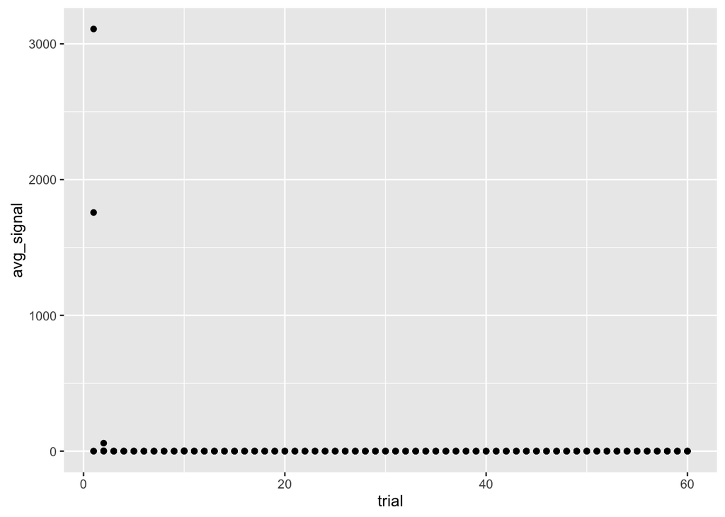

```r
pwr_long %>%
  group_by(block, trial, channel) %>%
  summarize(avg_signal = mean(signal)) %>%
  ggplot(aes(x = trial, y = avg_signal))+
    geom_point()
```

##### We now look at LI during the trial phase of interest: NF. First, we confirm the LI calculations. Indeed, these are easily confirmed as per the histogram. We then examine the grand average for a NF trial.

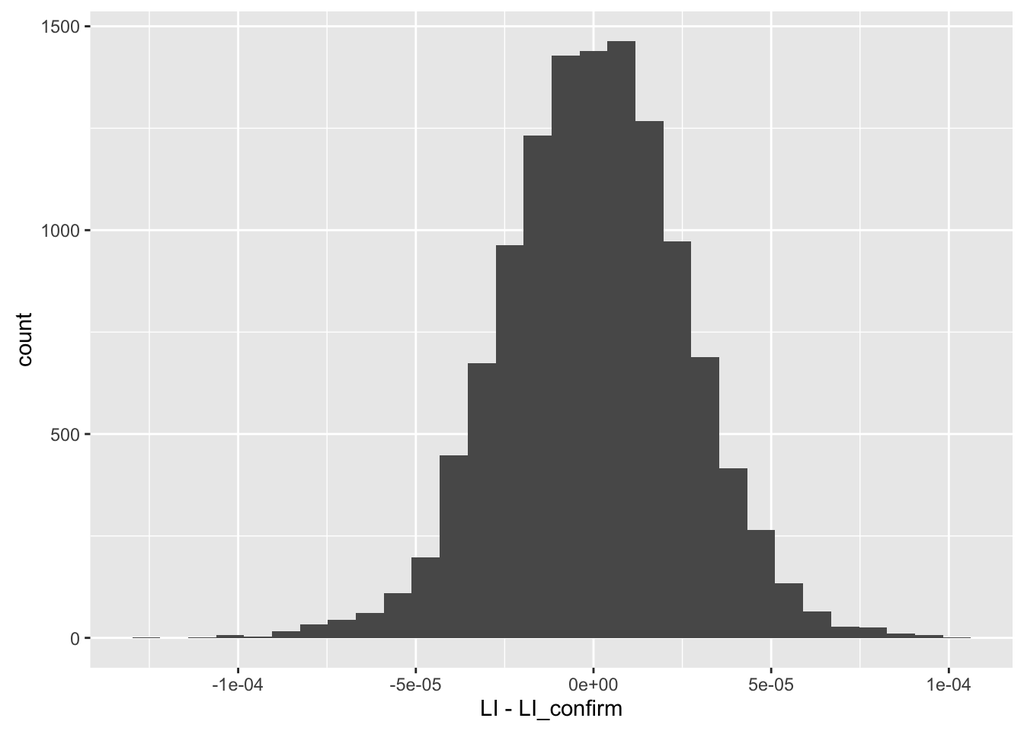

```r
pwr %>%
  dplyr::filter(trial_stage == "NF") %>%
  mutate(
    LI_confirm = ifelse(
        cue_loc == "right"
        , log2(C4/baseline_power_mavg) - log2(C3/baseline_power_mavg)
        , -(log2(C3/baseline_power_mavg) - log2(C4/baseline_power_mavg))
      )
    ) %>%
  ggplot()+
    geom_histogram(aes(x = LI - LI_confirm))
```

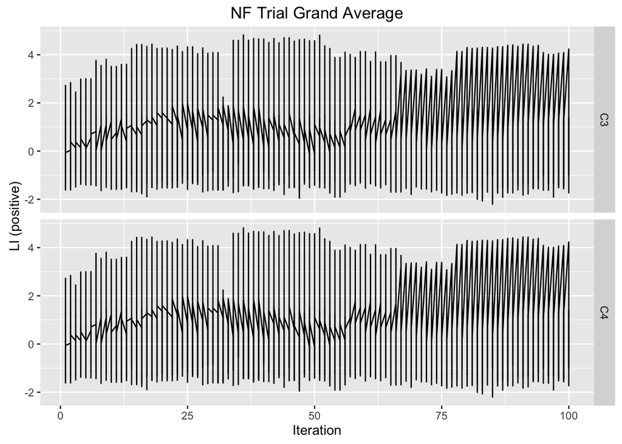

```r
pwr_long %>%
  mutate(
    LI_pos = ifelse(
        cue_loc == "right"
        , LI
        , -LI
      )
    ) %>%
  dplyr::filter(trial_stage == "NF") %>%
  group_by(block, trial,iteration, channel) %>%
  summarize(avg_LI = mean(LI_pos)) %>%
  ggplot(aes(y = avg_LI, x = iteration))+
    geom_line()+
    facet_grid(channel~.)+
    ggtitle("NF Trial Grand Average")+
    xlab("Iteration")+
    ylab("LI (positive)")
```